# TDB_relaxed functional composition

Katja Kozjek

# Load libraries

```r
library(rafalib) # nice plot arrangement
library(phyloseq)
library(ranacapa) #for rarefaction curves
library(ggplot2)
library(wesanderson)
library(DESeq2)
library(vegan)
library(ggordiplots)
library(scales)
library(dplyr)
library(tibble)
library(devtools)
library(pairwiseAdonis)
library(limma)
library(cowplot)
library(tidyverse)
```

Analyses related to functional composition. Counts are filtered using a function filterByExpr. PCA and PERMANOVA are conducted with and without batch correction approach. For overall composition, batch correction is on countries, for each country separately batch correction is on field pair. Envfit added to the overall functional composition, soil and plant parameters are pre-selected.

# Upload files

```r
tdb_fam <- read.csv("C:/Users/Katja/Box Sync/PhD Lund Katja/Sequencing/Functional_genes/Diamond/data_TDB/relaxed/TDB_EZfam_rem_filt.counts.tsv", sep = "\t", header = T, row.names = 1)

tdb_acc <- read.csv("C:/Users/Katja/Box Sync/PhD Lund Katja/Sequencing/Functional_genes/Diamond/data_TDB/relaxed/TDB_EZacc_rem_filt.counts.tsv",sep = "\t", header = T, row.names = 1)

metafile = read.csv("C:/Users/Katja/Box Sync/PhD Lund Katja/Sequencing/Functional_genes/Diamond/data_TDB/relaxed/metafile_relaxed.csv", sep=",", row.names=1)

metafile_remove <- metafile[-c(58,60),]

metafile_pca <- read.csv("C:/Users/Katja/Box Sync/PhD Lund Katja/Sequencing/Functional_genes/Diamond/data_TDB/relaxed/metafile_relaxed.csv", sep=",")
metafile_pca <- metafile_pca[-c(58,60),] #for pca dataframe

sampledata = sample_data(metafile)
sampledata_remove <- sampledata[-c(58,60),]
```

# PCA overall TDB EZfam

- using counts filterByExpr
- 2 Spanish samples are excluded

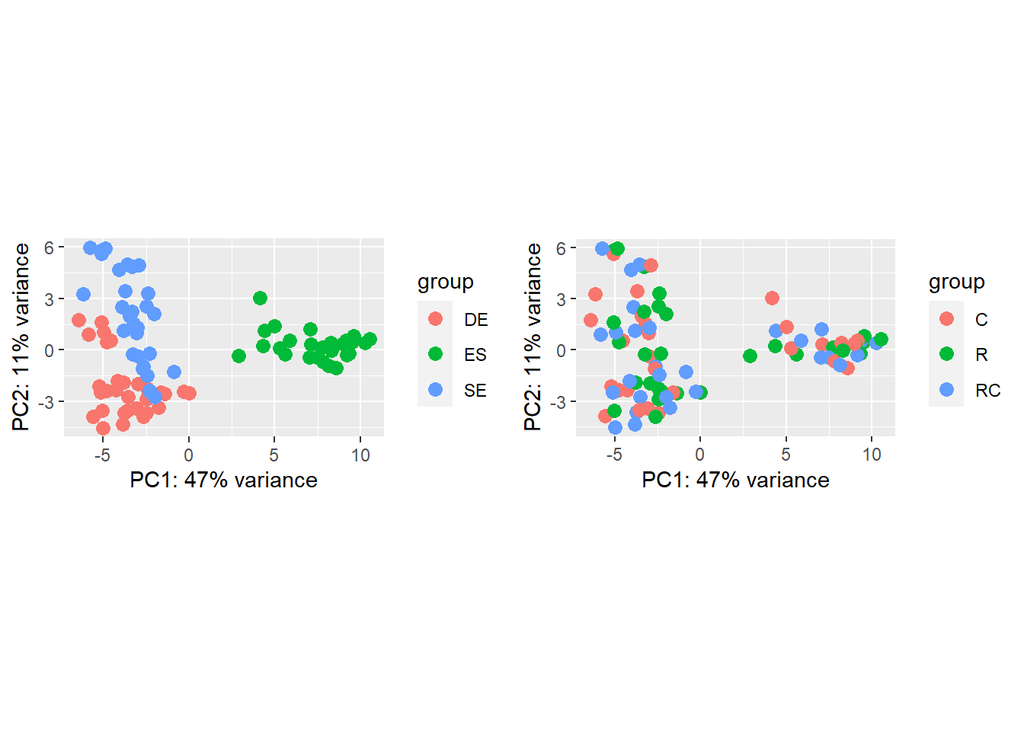

```r
dds_fam <- DESeqDataSetFromMatrix(countData = tdb_fam,
                              colData = metafile_remove,
                              design= ~ country + treatment)

vsd_fam <- varianceStabilizingTransformation(dds_fam)
vsd_fam_counts <- assay(vsd_fam)

p1_EZfam_country <- plotPCA(vsd_fam, "country")
p2_EZfam_treat <- plotPCA(vsd_fam, "treatment")
plot_grid(p1_EZfam_country, p2_EZfam_treat)
```

```r
#PERMANOVA

vsd_fam_counts <- t(vsd_fam_counts)
set.seed(4364)
adonis2(vsd_fam_counts ~ country*treatment,
       data=metafile_remove, strata=metafile_remove$plot, permutations=999)
```

```
## Permutation test for adonis under reduced model
## Terms added sequentially (first to last)
## Permutation: free
## Number of permutations: 999
##
## adonis2(formula = vsd_fam_counts ~ country * treatment, data = metafile_remove, permutations = 999, strata = metafile_remove$plot)
##                   Df SumOfSqs      R2       F Pr(>F)
## country            2 0.029732 0.50265 41.8435  0.001 ***
## treatment          2 0.000615 0.01040  0.8661  0.499
## country:treatment  4 0.000737 0.01246  0.5185  0.967
## Residual          79 0.028066 0.47449
## Total             87 0.059150 1.00000
## ---
## Signif. codes:  0 '***' 0.001 '**' 0.01 '*' 0.05 '.' 0.1 ' ' 1
```

*EZfam level, country effect*

## Nice PCA EZfam

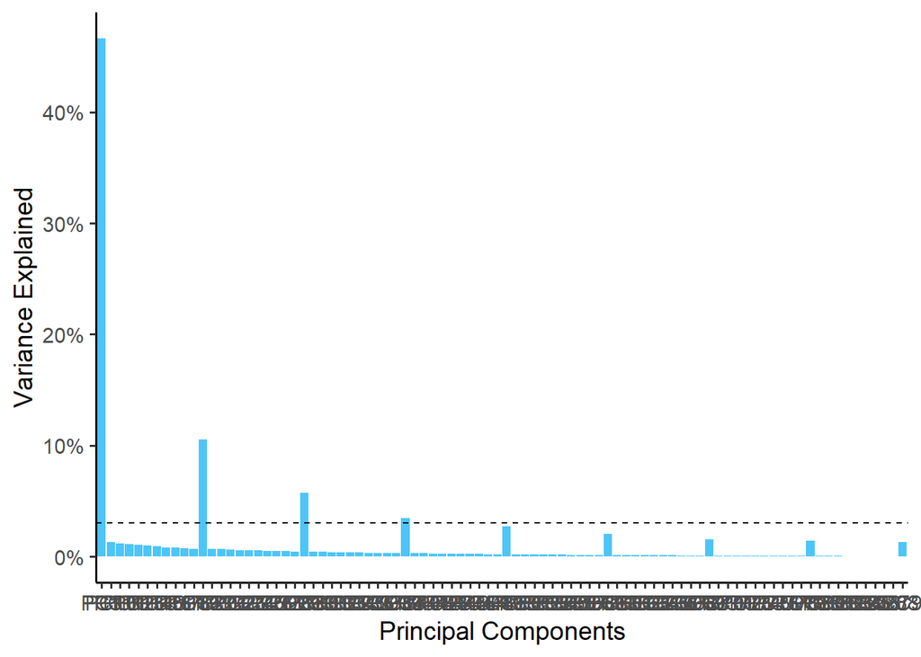

```r
#variance of components
frac_var <- function(x) x^2/sum(x^2)

vsd_fam_pca <- prcomp(vsd_fam_counts)

vsd_fam_pca$sdev %>%
  as_tibble() %>%
  frac_var() %>%
  mutate(Comp = colnames(vsd_fam_pca$x)) %>%
  ggplot(aes(x=Comp, y = value)) +
  geom_bar(stat = "identity", fill = "#4DC5F9") +
  geom_hline(yintercept = 0.03, linetype=2) +
  xlab("Principal Components") +
  scale_y_continuous(name = "Variance Explained", breaks = seq(0,0.8,0.1),
                     labels =   percent_format(accuracy = 5L)) +
  theme_classic(base_size = 14)
```

```r
vsd_fam_dframe <- vsd_fam_pca$x %>%
  as.data.frame() %>%
  rownames_to_column(var = "sample_ID") %>%
  full_join(metafile_pca, by = "sample_ID")

vsd_fam_dframe$treatment <- factor(vsd_fam_dframe$treatment,
                                        levels = c("C", "R", "RC"),
                                        labels = c("Control", "Roof", "Roof-Control"))

vsd_fam_dframe$country <- factor(vsd_fam_dframe$country,
                                      levels = c("SE", "DE", "ES"),
                                      labels = c("Sweden", "Germany", "Spain"))
#preselection for envfit
sampledata_env <- sampledata_remove[,-c(8,11,13,14,16,17,18,19,20,23,25)]

envfit_pca_EZfam_all <- gg_envfit(vsd_fam_pca, sampledata_env, perm = 9999, scaling=1, plot=F)
envfit_pca_EZfam_all$df_arrows
```

```
##                       x           y          var  p.val
## pH            2.7503642 -4.04937285           pH 0.0001
## VWC           0.6951647 -1.62688644          VWC 0.0225
## total.N      -4.7351572 -0.32974623      total.N 0.0001
## organic.C    -4.0859774  0.44811687    organic.C 0.0001
## total.P      -4.8264672 -1.24087811      total.P 0.0001
## WHC          -2.8946507  0.04462338          WHC 0.0001
## BD            2.8872016  3.34158111           BD 0.0001
## crop.biomass -4.5432266 -2.77761611 crop.biomass 0.0001
```

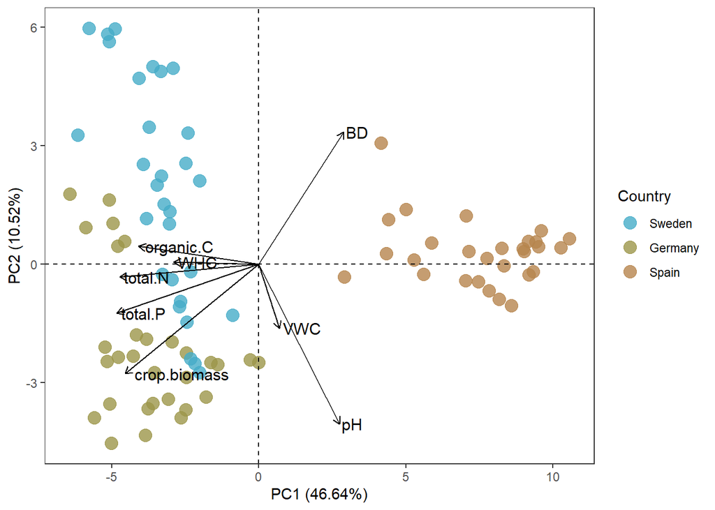

```r
pcaEZfam_overall <- ggplot(vsd_fam_dframe, aes(x=PC1, y=PC2, color = country)) +
  geom_point(size = 4,alpha=0.8) +
  geom_vline(xintercept = 0, linetype=2) +
  geom_hline(yintercept = 0, linetype=2) +
  theme_bw() +
  theme(panel.grid.major = element_blank(),
        panel.grid.minor = element_blank()) + labs(colour = "Country") +
  scale_color_manual(values = c("#46ACC8", "#9C964A", "#B6854D"))

pcaEZfam_overall_env <- pcaEZfam_overall + geom_segment(data = envfit_pca_EZfam_all$df_arrows,
               aes(x = 0, xend = x, y = 0, yend = y), color = "black",
               arrow = arrow(length = unit(0.2,"cm"))) +
               geom_text(data = envfit_pca_EZfam_all$df_arrows,
               aes(x = x, y = y, label = var), color = "black",
               size = 4,
               hjust = -0.1) + xlab("PC1 (46.64%)") + ylab("PC2 (10.52%)")

print(pcaEZfam_overall_env)
```

```r
#ggsave("/Users/Katja/Box Sync/PhD Lund Katja/Sequencing/Functional_genes/Diamond/data_TDB/relaxed/results/pca_env_TDB_EZfam.jpeg", width = 30, height = 15, units = "cm")
```

### Batch correction on countries EZfam

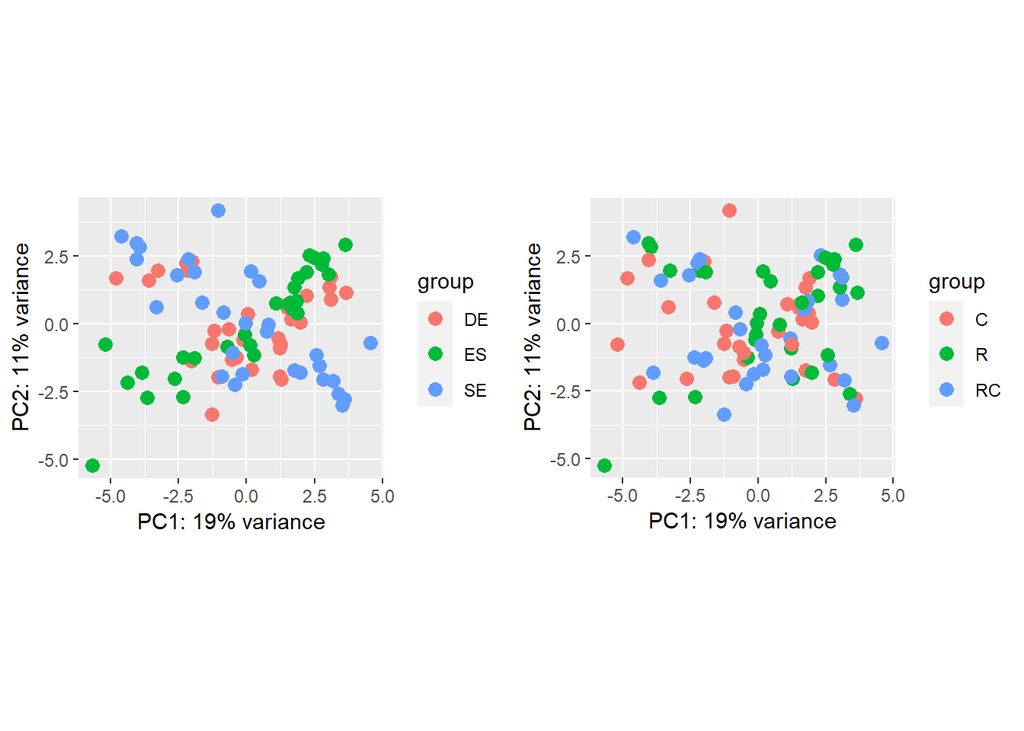

```r
vsd_fam_remCOUNTRY <- vsd_fam
assay(vsd_fam_remCOUNTRY) <- limma::removeBatchEffect(assay(vsd_fam_remCOUNTRY), vsd_fam_remCOUNTRY$country)

p1_EZfam_country_corr <- plotPCA(vsd_fam_remCOUNTRY, "country")
p2_EZfam_treat_corr <- plotPCA(vsd_fam_remCOUNTRY, "treatment")
plot_grid(p1_EZfam_country_corr, p2_EZfam_treat_corr)
```

```r
vsd_fam_remCOUNTRY_df <- as.data.frame(assay(vsd_fam_remCOUNTRY))
vsd_fam_remCOUNTRY_df <- t(vsd_fam_remCOUNTRY_df)

set.seed(4364)
adonis2(vsd_fam_remCOUNTRY_df ~ treatment,
                     data=metafile_remove, strata=metafile_remove$plot, permutations=999)
```

```
## Permutation test for adonis under reduced model
## Terms added sequentially (first to last)
## Permutation: free
## Number of permutations: 999
##
## adonis2(formula = vsd_fam_remCOUNTRY_df ~ treatment, data = metafile_remove, permutations = 999, strata = metafile_remove$plot)
##           Df  SumOfSqs      R2      F Pr(>F)
## treatment  2 0.0005829 0.01962 0.8507  0.705
## Residual  85 0.0291243 0.98038
## Total     87 0.0297073 1.00000
```

*No drought effect on overall functional composition EZfam after batch correction*

# PCA overall TDB EZacc

- using counts filterByExpr
- 2 Spanish samples are excluded

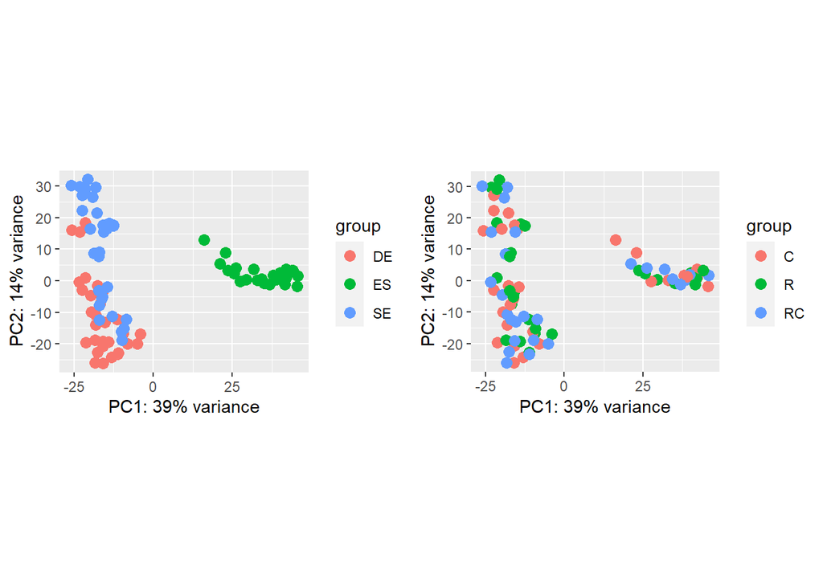

```r
dds_acc <- DESeqDataSetFromMatrix(countData = tdb_acc,
                              colData = metafile_remove,
                              design= ~ country + treatment)

vsd_acc <- varianceStabilizingTransformation(dds_acc)
vsd_acc_counts <- assay(vsd_acc)

p1_EZacc_country <- plotPCA(vsd_acc, "country")
p2_EZfam_treat <- plotPCA(vsd_acc, "treatment")
plot_grid(p1_EZacc_country, p2_EZfam_treat)
```

```r
#PERMANOVA

vsd_acc_counts <- t(vsd_acc_counts)
set.seed(4364)
adonis2(vsd_acc_counts ~ country*treatment,
       data=metafile_remove, strata=metafile_remove$plot, permutations=999)
```

```
## Permutation test for adonis under reduced model
## Terms added sequentially (first to last)
## Permutation: free
## Number of permutations: 999
##
## adonis2(formula = vsd_acc_counts ~ country * treatment, data = metafile_remove, permutations = 999, strata = metafile_remove$plot)
##                   Df SumOfSqs      R2       F Pr(>F)
## country            2  0.26962 0.38425 25.9620  0.001 ***
## treatment          2  0.00766 0.01092  0.7375  0.769
## country:treatment  4  0.01418 0.02021  0.6828  0.931
## Residual          79  0.41021 0.58462
## Total             87  0.70167 1.00000
## ---
## Signif. codes:  0 '***' 0.001 '**' 0.01 '*' 0.05 '.' 0.1 ' ' 1
```

*EZacc level, country effect*

## Nice PCA EZacc

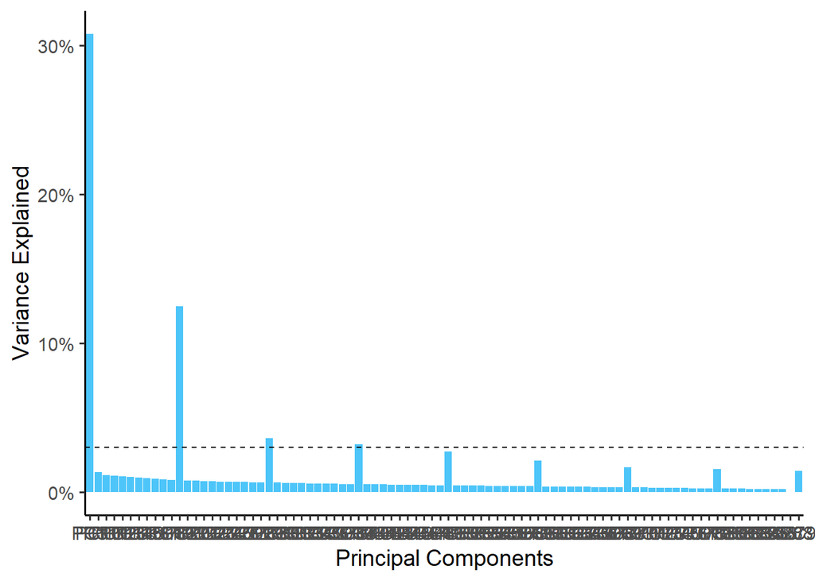

```r
vsd_acc_pca <- prcomp(vsd_acc_counts)

vsd_acc_pca$sdev %>%
  as_tibble() %>%
  frac_var() %>%
  mutate(Comp = colnames(vsd_acc_pca$x)) %>%
  ggplot(aes(x=Comp, y = value)) +
  geom_bar(stat = "identity", fill = "#4DC5F9") +
  geom_hline(yintercept = 0.03, linetype=2) +
  xlab("Principal Components") +
  scale_y_continuous(name = "Variance Explained", breaks = seq(0,0.8,0.1),
                     labels =   percent_format(accuracy = 5L)) +
  theme_classic(base_size = 14)
```

```r
vsd_acc_dframe <- vsd_acc_pca$x %>%
  as.data.frame() %>%
  rownames_to_column(var = "sample_ID") %>%
  full_join(metafile_pca, by = "sample_ID")

vsd_acc_dframe$treatment <- factor(vsd_acc_dframe$treatment,
                                        levels = c("C", "R", "RC"),
                                        labels = c("Control", "Roof", "Roof-Control"))

vsd_acc_dframe$country <- factor(vsd_acc_dframe$country,
                                      levels = c("SE", "DE", "ES"),
                                      labels = c("Sweden", "Germany", "Spain"))

envfit_pca_EZacc_all <- gg_envfit(vsd_acc_pca, sampledata_env, perm = 9999, scaling=1, plot=F)
envfit_pca_EZacc_all$df_arrows
```

```
##                       x           y          var  p.val
## pH            17.780331 -17.4894707           pH 0.0001
## VWC            5.275026  -8.9666848          VWC 0.0053
## total.N      -24.904378  -2.9574478      total.N 0.0001
## organic.C    -21.808151   0.8293762    organic.C 0.0001
## total.P      -25.347769  -2.6929273      total.P 0.0001
## WHC          -15.133478   1.0982757          WHC 0.0001
## BD            17.144341  13.7223132           BD 0.0001
## crop.biomass -24.690550 -10.6528227 crop.biomass 0.0001
```

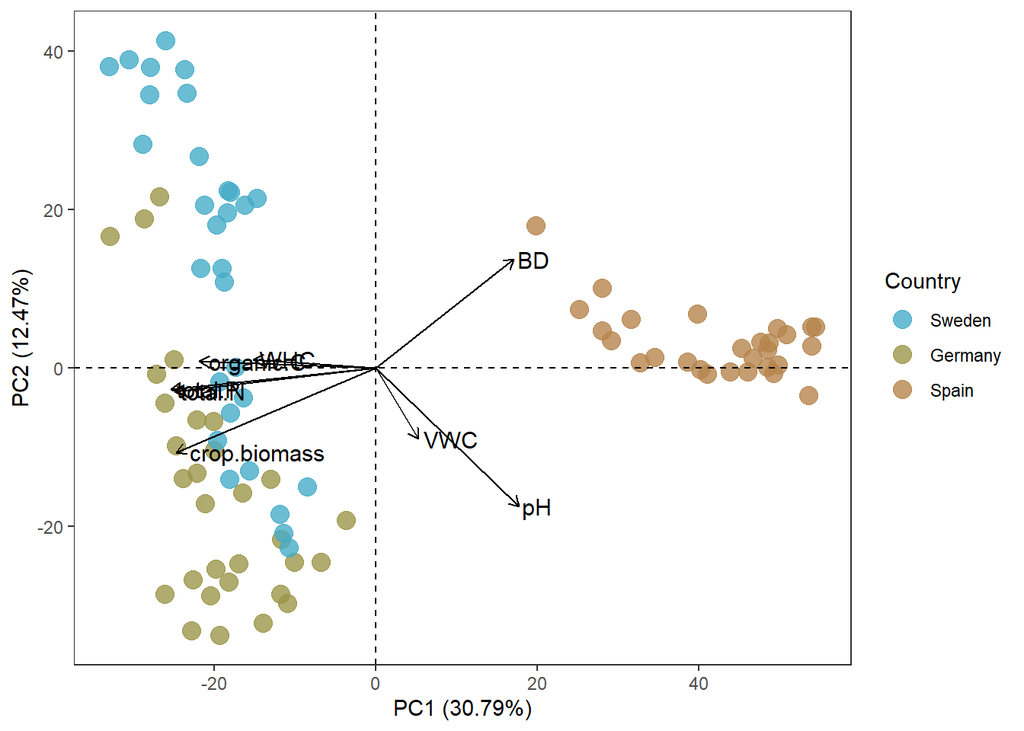

```r
pcaEZacc_overall <- ggplot(vsd_acc_dframe, aes(x=PC1, y=PC2, color = country)) +
  geom_point(size = 4,alpha=0.8) +
  geom_vline(xintercept = 0, linetype=2) +
  geom_hline(yintercept = 0, linetype=2) +
  theme_bw() +
  theme(panel.grid.major = element_blank(),
        panel.grid.minor = element_blank()) + labs(colour = "Country") +
  scale_color_manual(values = c("#46ACC8", "#9C964A", "#B6854D"))

pcaEZacc_overall_env <- pcaEZacc_overall + geom_segment(data = envfit_pca_EZacc_all$df_arrows,
               aes(x = 0, xend = x, y = 0, yend = y), color = "black",
               arrow = arrow(length = unit(0.2,"cm"))) +
               geom_text(data = envfit_pca_EZacc_all$df_arrows,
               aes(x = x, y = y, label = var), color = "black",
               size = 4,
               hjust = -0.1) + xlab("PC1 (30.79%)") + ylab("PC2 (12.47%)")

print(pcaEZacc_overall_env)
```

```r
#ggsave("/Users/Katja/Box Sync/PhD Lund Katja/Sequencing/Functional_genes/Diamond/data_TDB/relaxed/results/pca_env_TDB_EZacc.jpeg", width = 30, height = 15, units = "cm")
```

### Batch correction on countries EZacc

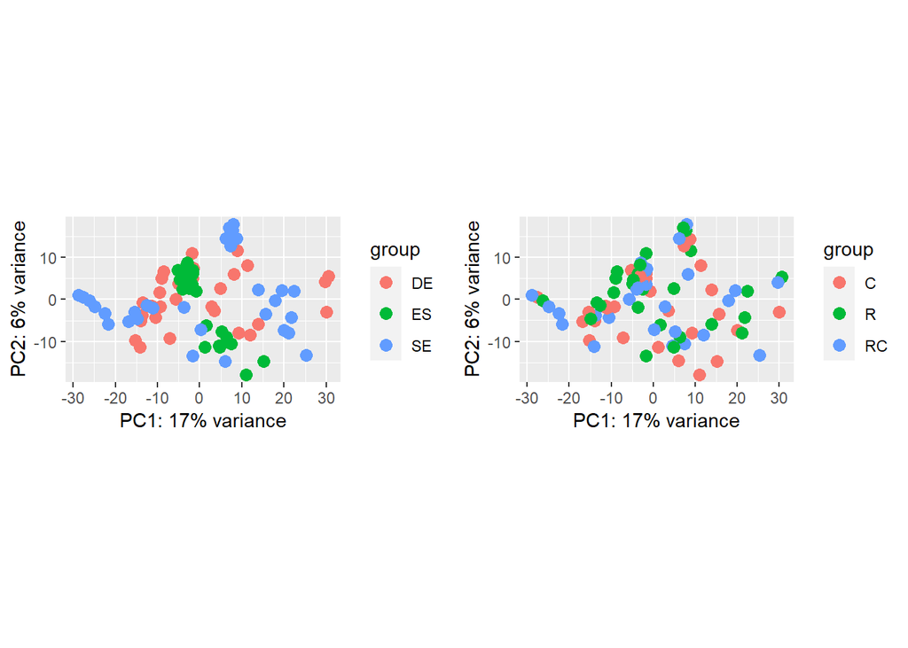

```r
vsd_acc_remCOUNTRY <- vsd_acc
assay(vsd_acc_remCOUNTRY) <- limma::removeBatchEffect(assay(vsd_acc_remCOUNTRY), vsd_acc_remCOUNTRY$country)

p1_EZacc_country_corr <- plotPCA(vsd_acc_remCOUNTRY, "country")
p2_EZacc_treat_corr <- plotPCA(vsd_acc_remCOUNTRY, "treatment")
plot_grid(p1_EZacc_country_corr, p2_EZacc_treat_corr)
```

```r
vsd_acc_remCOUNTRY_df <- as.data.frame(assay(vsd_acc_remCOUNTRY))
vsd_acc_remCOUNTRY_df <- t(vsd_acc_remCOUNTRY_df)

#PERMANOVA

set.seed(4364)
adonis2(vsd_acc_remCOUNTRY_df ~ treatment,
                     data=metafile_remove, strata=metafile_remove$plot, permutations=999)
```

```
## Permutation test for adonis under reduced model
## Terms added sequentially (first to last)
## Permutation: free
## Number of permutations: 999
##
## adonis2(formula = vsd_acc_remCOUNTRY_df ~ treatment, data = metafile_remove, permutations = 999, strata = metafile_remove$plot)
##           Df SumOfSqs      R2      F Pr(>F)
## treatment  2  0.00770 0.01748 0.7563  0.976
## Residual  85  0.43285 0.98252
## Total     87  0.44055 1.00000
```

*No drought effect on overall functional composition EZacc after batch correction*

# Sweden

## EZfam level

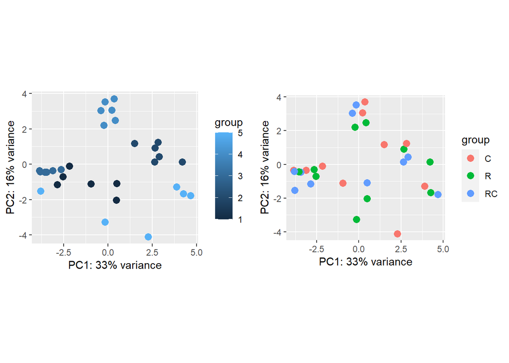

```r
se_metadat <- metafile_remove %>%
  filter(country == "SE")

se_tdb_fam <- tdb_fam[,colnames(tdb_fam) %in% rownames(se_metadat)]

se_dds_fam <- DESeqDataSetFromMatrix(countData = se_tdb_fam,
                              colData = se_metadat[match(colnames(se_tdb_fam), rownames(se_metadat)), ],
                              design= ~ field_pair + treatment)

se_vsd_fam <- varianceStabilizingTransformation(se_dds_fam)
se_vsd_fam_counts <- assay(se_vsd_fam)

p1_SE_FP <- plotPCA(se_vsd_fam, "field_pair")
p2_SE_treat <- plotPCA(se_vsd_fam, "treatment")
plot_grid(p1_SE_FP, p2_SE_treat)
```

```r
#PERMANOVA
se_vsd_fam_counts <- t(se_vsd_fam_counts)
set.seed(4364)
adonis2(se_vsd_fam_counts~ treatment,
       data=se_metadat, strata=se_metadat$field_pair, permutations=999)
```

```
## Permutation test for adonis under reduced model
## Terms added sequentially (first to last)
## Permutation: free
## Number of permutations: 999
##
## adonis2(formula = se_vsd_fam_counts ~ treatment, data = se_metadat, permutations = 999, strata = se_metadat$field_pair)
##           Df  SumOfSqs      R2    F Pr(>F)
## treatment  2 0.0002369 0.03641 0.51  0.989
## Residual  27 0.0062712 0.96359
## Total     29 0.0065082 1.00000
```

*No drought effect on family level*

### batch correction

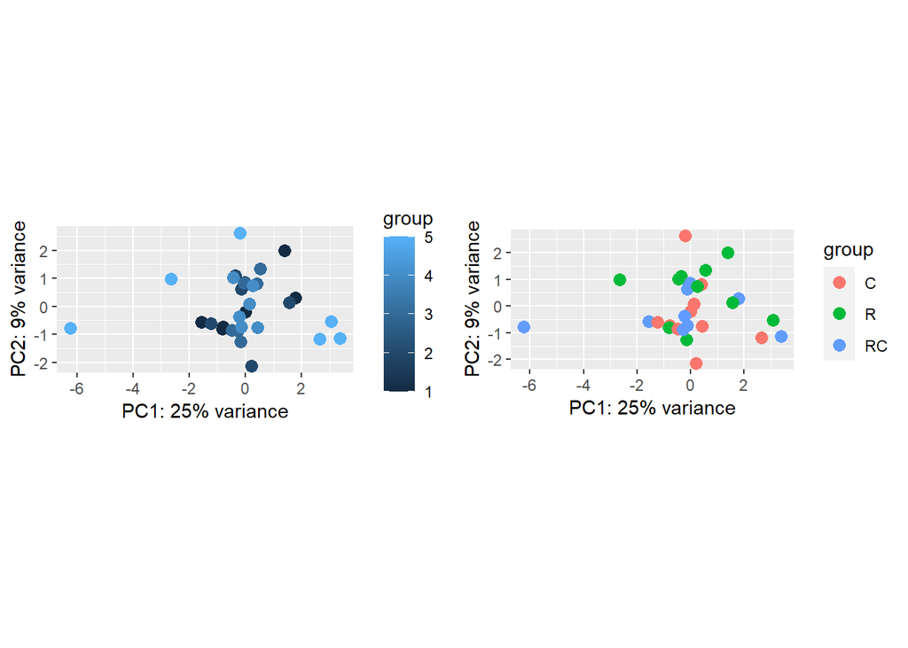

```r
se_vsd_fam_remFP <- se_vsd_fam
assay(se_vsd_fam_remFP) <- limma::removeBatchEffect(assay(se_vsd_fam_remFP), se_vsd_fam_remFP$field_pair)

p1_SE_FP_corr <- plotPCA(se_vsd_fam_remFP, "field_pair")
p2_SE_treat_corr <- plotPCA(se_vsd_fam_remFP, "treatment")
plot_grid(p1_SE_FP_corr, p2_SE_treat_corr)
```

```r
#PERMANOVA
se_vsd_fam_remFP_df <- as.data.frame(assay(se_vsd_fam_remFP))
se_vsd_fam_remFP_df <- t(se_vsd_fam_remFP_df)

set.seed(4364)
adonis2(se_vsd_fam_remFP_df ~ treatment,
                     data=se_metadat, permutations=999)
```

```
## Permutation test for adonis under reduced model
## Terms added sequentially (first to last)
## Permutation: free
## Number of permutations: 999
##
## adonis2(formula = se_vsd_fam_remFP_df ~ treatment, data = se_metadat, permutations = 999)
##           Df  SumOfSqs      R2      F Pr(>F)
## treatment  2 0.0002566 0.07156 1.0405  0.365
## Residual  27 0.0033299 0.92844
## Total     29 0.0035865 1.00000
```

*No drought effect on family level after batch correction on field pairs*

## EZ ID level

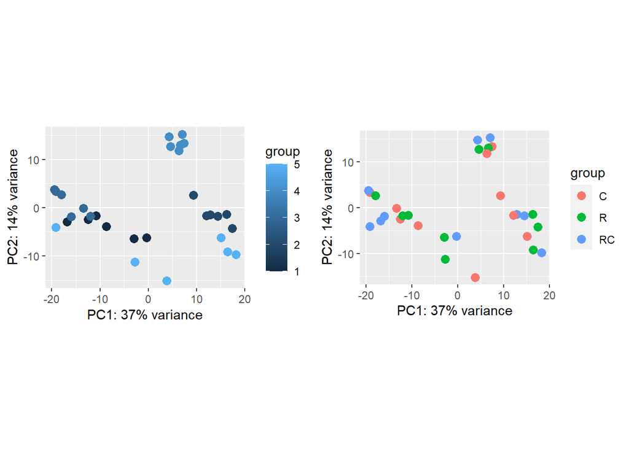

```r
se_tdb_acc <- tdb_acc[,colnames(tdb_acc) %in% rownames(se_metadat)]

se_dds_acc <- DESeqDataSetFromMatrix(countData = se_tdb_acc,
                              colData = se_metadat[match(colnames(se_tdb_acc), rownames(se_metadat)), ],
                              design= ~ field_pair + treatment)

se_vsd_acc <- varianceStabilizingTransformation(se_dds_acc)
se_vsd_acc_counts <- assay(se_vsd_acc)

p1_SEacc_FP <- plotPCA(se_vsd_acc, "field_pair")
p2_SEacc_treat <- plotPCA(se_vsd_acc, "treatment")
plot_grid(p1_SEacc_FP, p2_SEacc_treat)
```

```r
#PERMANOVA
se_vsd_acc_counts <- t(se_vsd_acc_counts)
set.seed(4364)
adonis2(se_vsd_acc_counts ~ treatment,
       data=se_metadat, strata=se_metadat$field_pair, permutations=999)
```

```
## Permutation test for adonis under reduced model
## Terms added sequentially (first to last)
## Permutation: free
## Number of permutations: 999
##
## adonis2(formula = se_vsd_acc_counts ~ treatment, data = se_metadat, permutations = 999, strata = se_metadat$field_pair)
##           Df SumOfSqs      R2      F Pr(>F)
## treatment  2 0.002384 0.04067 0.5723  0.995
## Residual  27 0.056234 0.95933
## Total     29 0.058618 1.00000
```

*No drought effect on ID level*

### batch correction

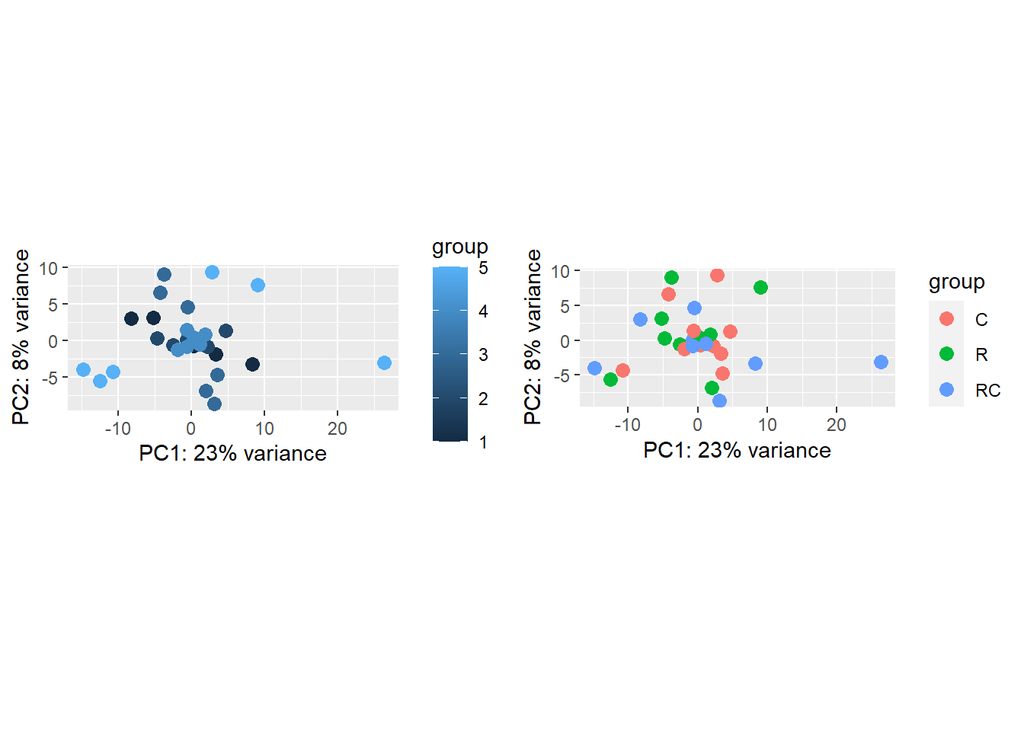

```r
se_vsd_acc_remFP <- se_vsd_acc
assay(se_vsd_acc_remFP) <- limma::removeBatchEffect(assay(se_vsd_acc_remFP), se_vsd_acc_remFP$field_pair)

p1_SEacc_FP_corr <- plotPCA(se_vsd_acc_remFP, "field_pair")
p2_SEacc_treat_corr <- plotPCA(se_vsd_acc_remFP, "treatment")
plot_grid(p1_SEacc_FP_corr, p2_SEacc_treat_corr)
```

```r
#PERMANOVA
se_vsd_acc_remFP_df <- as.data.frame(assay(se_vsd_acc_remFP))
se_vsd_acc_remFP_df <- t(se_vsd_acc_remFP_df)

set.seed(4364)
adonis2(se_vsd_acc_remFP_df ~ treatment,
                     data=se_metadat, permutations=999)
```

```
## Permutation test for adonis under reduced model
## Terms added sequentially (first to last)
## Permutation: free
## Number of permutations: 999
##
## adonis2(formula = se_vsd_acc_remFP_df ~ treatment, data = se_metadat, permutations = 999)
##           Df SumOfSqs      R2      F Pr(>F)
## treatment  2 0.002403 0.07105 1.0326  0.363
## Residual  27 0.031411 0.92895
## Total     29 0.033813 1.00000
```

*No drought effect on ID level after batch correction*

# Germany

## EZfam level

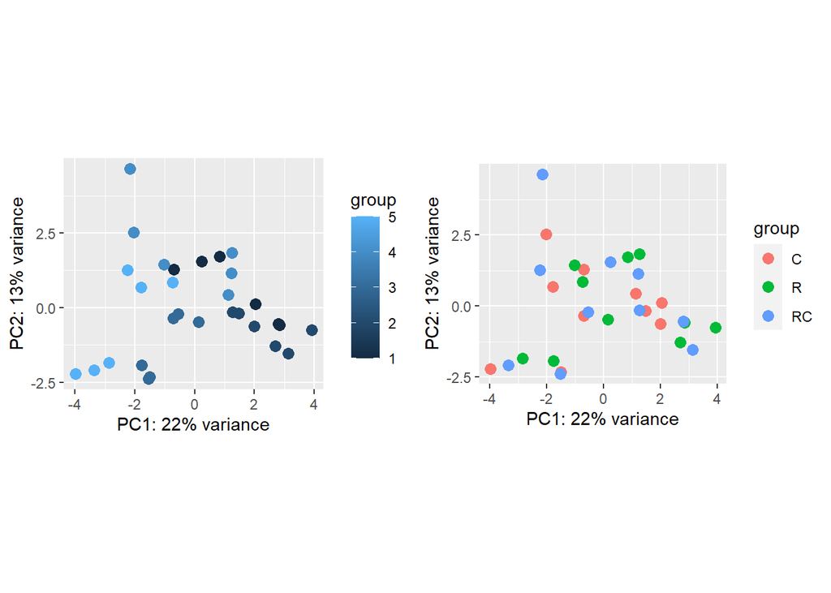

```r
de_metadat <- metafile_remove %>%
  filter(country == "DE")

de_tdb_fam <- tdb_fam[,colnames(tdb_fam) %in% rownames(de_metadat)]

de_dds_fam <- DESeqDataSetFromMatrix(countData = de_tdb_fam,
                              colData = de_metadat[match(colnames(de_tdb_fam), rownames(de_metadat)), ],
                              design= ~ field_pair + treatment)

de_vsd_fam <- varianceStabilizingTransformation(de_dds_fam)
de_vsd_fam_counts <- assay(de_vsd_fam)

p1_DE_FP <- plotPCA(de_vsd_fam, "field_pair")
p2_DE_treat <- plotPCA(de_vsd_fam, "treatment")
plot_grid(p1_DE_FP, p2_DE_treat)
```

```r
#PERMANOVA
de_vsd_fam_counts <- t(de_vsd_fam_counts)
set.seed(4364)
adonis2(de_vsd_fam_counts~ treatment,
       data=de_metadat, strata=de_metadat$field_pair, permutations=999)
```

```
## Permutation test for adonis under reduced model
## Terms added sequentially (first to last)
## Permutation: free
## Number of permutations: 999
##
## adonis2(formula = de_vsd_fam_counts ~ treatment, data = de_metadat, permutations = 999, strata = de_metadat$field_pair)
##           Df  SumOfSqs      R2      F Pr(>F)
## treatment  2 0.0003497 0.06032 0.8666  0.655
## Residual  27 0.0054482 0.93968
## Total     29 0.0057979 1.00000
```

*No drought effect on family level*

### batch correction

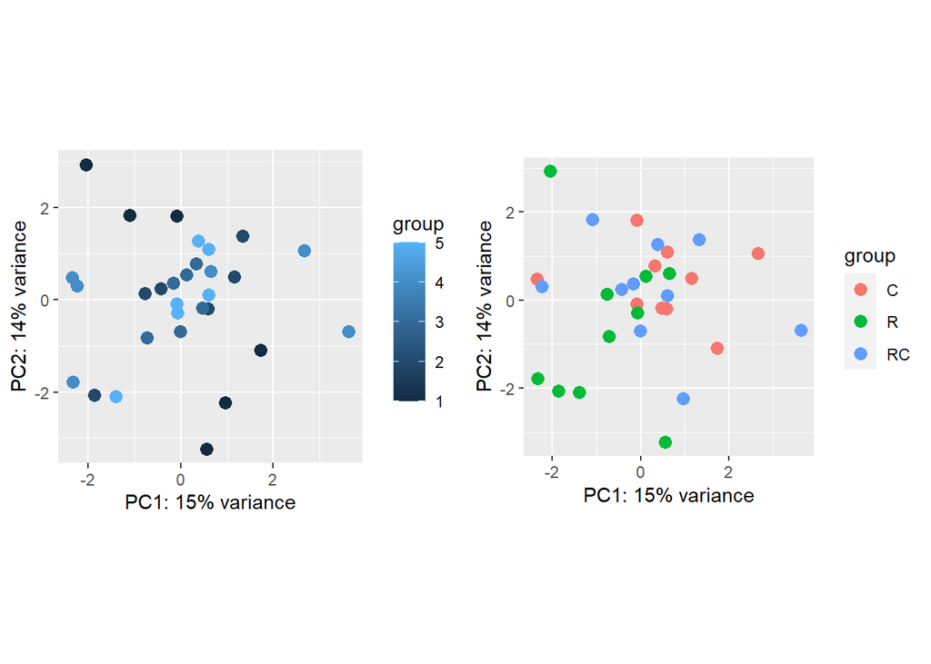

```r
de_vsd_fam_remFP <- de_vsd_fam
assay(de_vsd_fam_remFP) <- limma::removeBatchEffect(assay(de_vsd_fam_remFP), de_vsd_fam_remFP$field_pair)

p1_DE_FP_corr <- plotPCA(de_vsd_fam_remFP, "field_pair")
p2_DE_treat_corr <- plotPCA(de_vsd_fam_remFP, "treatment")
plot_grid(p1_DE_FP_corr, p2_DE_treat_corr)
```

```r
#PERMANOVA
de_vsd_fam_remFP_df <- as.data.frame(assay(de_vsd_fam_remFP))
de_vsd_fam_remFP_df <- t(de_vsd_fam_remFP_df)

set.seed(4364)
adonis2(de_vsd_fam_remFP_df ~ treatment,
                     data=de_metadat, permutations=999)
```

```
## Permutation test for adonis under reduced model
## Terms added sequentially (first to last)
## Permutation: free
## Number of permutations: 999
##
## adonis2(formula = de_vsd_fam_remFP_df ~ treatment, data = de_metadat, permutations = 999)
##           Df  SumOfSqs      R2      F Pr(>F)
## treatment  2 0.0003414 0.09128 1.3561  0.061 .
## Residual  27 0.0033986 0.90872
## Total     29 0.0037400 1.00000
## ---
## Signif. codes:  0 '***' 0.001 '**' 0.01 '*' 0.05 '.' 0.1 ' ' 1
```

*Slight drought effect on family level after batch correction*

## EZ ID level

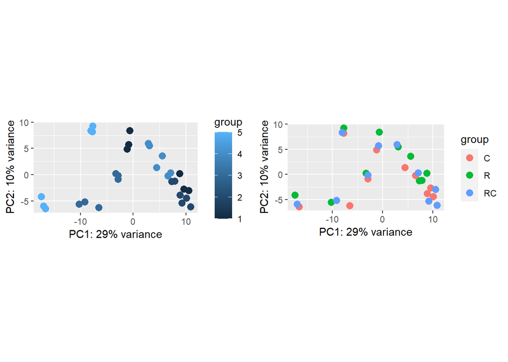

```r
de_tdb_acc <- tdb_acc[,colnames(tdb_acc) %in% rownames(de_metadat)]

de_dds_acc <- DESeqDataSetFromMatrix(countData = de_tdb_acc,
                              colData = de_metadat[match(colnames(de_tdb_acc), rownames(de_metadat)), ],
                              design= ~ field_pair + treatment)

de_vsd_acc <- varianceStabilizingTransformation(de_dds_acc)
de_vsd_acc_counts <- assay(de_vsd_acc)

p1_DEacc_FP <- plotPCA(de_vsd_acc, "field_pair")
p2_DEacc_treat <- plotPCA(de_vsd_acc, "treatment")
plot_grid(p1_DEacc_FP, p2_DEacc_treat)
```

```r
#PERMANOVA
de_vsd_acc_counts <- t(de_vsd_acc_counts)
set.seed(4364)
adonis2(de_vsd_acc_counts ~ treatment,
                     data=de_metadat, strata=de_metadat$field_pair, permutations=999)
```

```
## Permutation test for adonis under reduced model
## Terms added sequentially (first to last)
## Permutation: free
## Number of permutations: 999
##
## adonis2(formula = de_vsd_acc_counts ~ treatment, data = de_metadat, permutations = 999, strata = de_metadat$field_pair)
##           Df SumOfSqs      R2      F Pr(>F)
## treatment  2 0.001938 0.05662 0.8103  0.836
## Residual  27 0.032287 0.94338
## Total     29 0.034225 1.00000
```

*No drought effect on ID level*

### batch correction

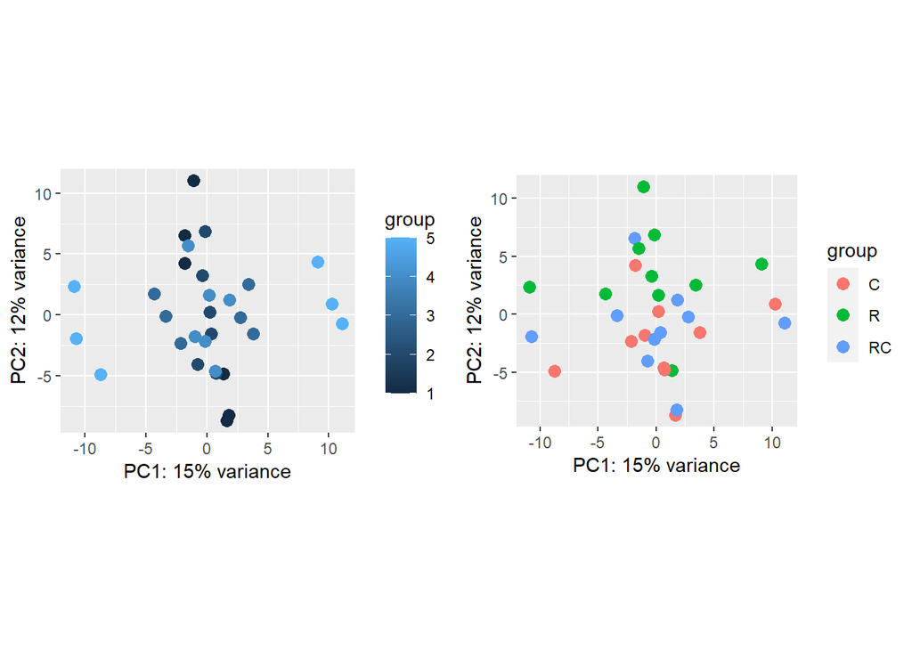

```r
de_vsd_acc_remFP <- de_vsd_acc
assay(de_vsd_acc_remFP) <- limma::removeBatchEffect(assay(de_vsd_acc_remFP), de_vsd_acc_remFP$field_pair)

p1_DEacc_FP_corr <- plotPCA(de_vsd_acc_remFP, "field_pair")
p2_DEacc_treat_corr <- plotPCA(de_vsd_acc_remFP, "treatment")
plot_grid(p1_DEacc_FP_corr, p2_DEacc_treat_corr)
```

```r
#PERMANOVA
de_vsd_acc_remFP_df <- as.data.frame(assay(de_vsd_acc_remFP))
de_vsd_acc_remFP_df <- t(de_vsd_acc_remFP_df)

set.seed(4364)
adonis2(de_vsd_acc_remFP_df ~ treatment,
                     data=de_metadat, permutations=999)
```

```
## Permutation test for adonis under reduced model
## Terms added sequentially (first to last)
## Permutation: free
## Number of permutations: 999
##
## adonis2(formula = de_vsd_acc_remFP_df ~ treatment, data = de_metadat, permutations = 999)
##           Df  SumOfSqs      R2      F Pr(>F)
## treatment  2 0.0019223 0.08534 1.2596  0.053 .
## Residual  27 0.0206020 0.91466
## Total     29 0.0225242 1.00000
## ---
## Signif. codes:  0 '***' 0.001 '**' 0.01 '*' 0.05 '.' 0.1 ' ' 1
```

*Slight drought effect on ID level after batch correction*

# Spain

## EZfam level

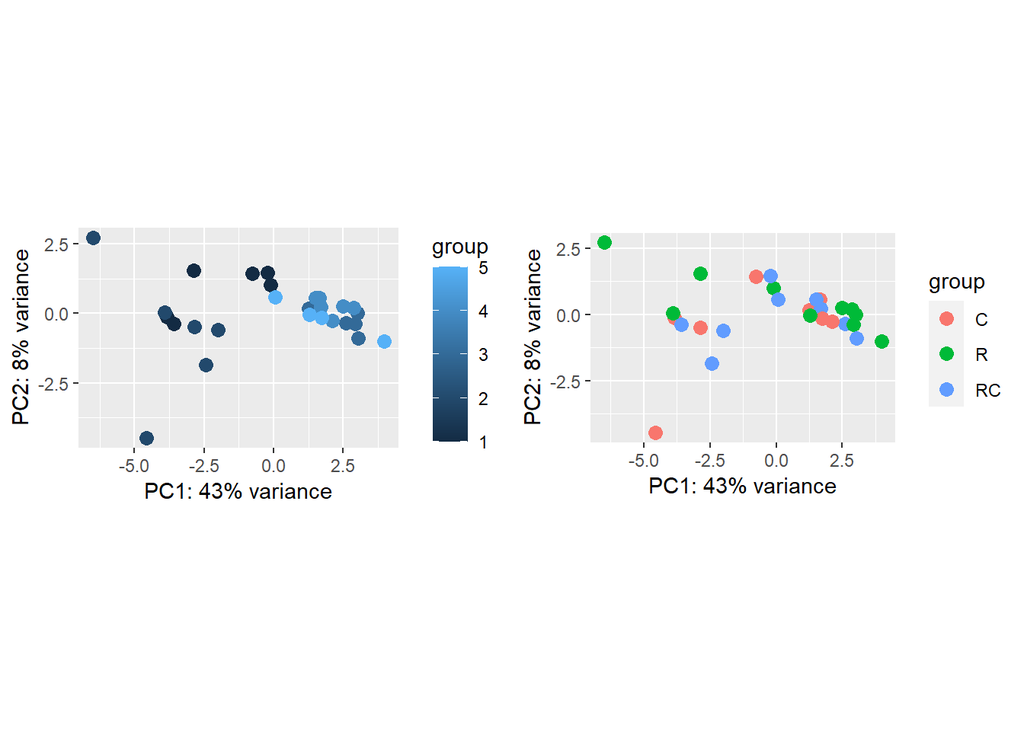

```r
es_metadat <- metafile_remove %>%
  filter(country == "ES")

es_tdb_fam <- tdb_fam[,colnames(tdb_fam) %in% rownames(es_metadat)]

es_dds_fam <- DESeqDataSetFromMatrix(countData = es_tdb_fam,
                              colData = es_metadat[match(colnames(es_tdb_fam), rownames(es_metadat)), ],
                              design= ~ field_pair + treatment)

es_vsd_fam <- varianceStabilizingTransformation(es_dds_fam)
es_vsd_fam_counts <- assay(es_vsd_fam)

p1_ES_EP <- plotPCA(es_vsd_fam, "field_pair")
p2_ES_treat <- plotPCA(es_vsd_fam, "treatment")
plot_grid(p1_ES_EP, p2_ES_treat)
```

```r
#PERMANOVA
es_vsd_fam_counts <- t(es_vsd_fam_counts)
set.seed(4364)
adonis2(es_vsd_fam_counts ~ treatment,
       data=es_metadat, strata=es_metadat$field_pair, permutations=999)
```

```
## Permutation test for adonis under reduced model
## Terms added sequentially (first to last)
## Permutation: free
## Number of permutations: 999
##
## adonis2(formula = es_vsd_fam_counts ~ treatment, data = es_metadat, permutations = 999, strata = es_metadat$field_pair)
##           Df  SumOfSqs      R2      F Pr(>F)
## treatment  2 0.0001609 0.03709 0.4814  0.981
## Residual  25 0.0041774 0.96291
## Total     27 0.0043383 1.00000
```

*No drought on family level*

### batch correction

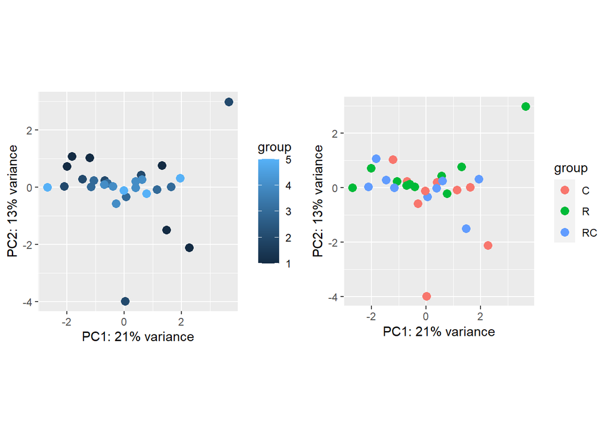

```r
es_vsd_fam_remFP <- es_vsd_fam
assay(es_vsd_fam_remFP) <- limma::removeBatchEffect(assay(es_vsd_fam_remFP), es_vsd_fam_remFP$field_pair)

p1_ES_EP_corr <- plotPCA(es_vsd_fam_remFP, "field_pair")
p2_ES_treat_corr <- plotPCA(es_vsd_fam_remFP, "treatment")
plot_grid(p1_ES_EP_corr, p2_ES_treat_corr)
```

```r
#PERMANOVA
es_vsd_fam_remFP_df <- as.data.frame(assay(es_vsd_fam_remFP))
es_vsd_fam_remFP_df <- t(es_vsd_fam_remFP_df)

set.seed(4364)
adonis2(es_vsd_fam_remFP_df ~ treatment,
                     data=es_metadat, permutations=999)
```

```
## Permutation test for adonis under reduced model
## Terms added sequentially (first to last)
## Permutation: free
## Number of permutations: 999
##
## adonis2(formula = es_vsd_fam_remFP_df ~ treatment, data = es_metadat, permutations = 999)
##           Df   SumOfSqs      R2      F Pr(>F)
## treatment  2 0.00015269 0.06441 0.8606  0.709
## Residual  25 0.00221779 0.93559
## Total     27 0.00237048 1.00000
```

*No drought on family level after batch correction*

## EZ ID level

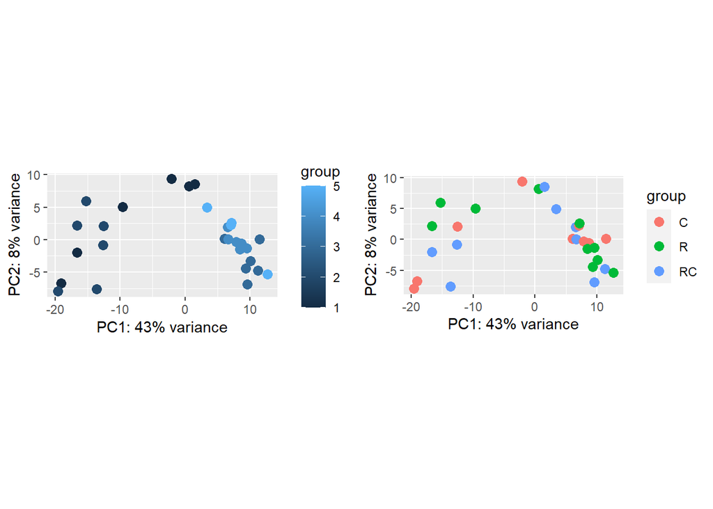

```r
es_tdb_acc <- tdb_acc[,colnames(tdb_acc) %in% rownames(es_metadat)]

es_dds_acc <- DESeqDataSetFromMatrix(countData = es_tdb_acc,
                              colData = es_metadat[match(colnames(es_tdb_acc), rownames(es_metadat)), ],
                              design= ~ field_pair + treatment)

es_vsd_acc <- varianceStabilizingTransformation(es_dds_acc)
es_vsd_acc_counts <- assay(es_vsd_acc)

p1_ESacc_EP <- plotPCA(es_vsd_acc, "field_pair")
p2_ESacc_treat <- plotPCA(es_vsd_acc, "treatment")
plot_grid(p1_ESacc_EP, p2_ESacc_treat)
```

```r
#PERMANOVA
es_vsd_acc_counts <- t(es_vsd_acc_counts)
set.seed(4364)
adonis2(es_vsd_acc_counts ~ treatment,
                     data=es_metadat, strata=es_metadat$field_pair, permutations=999)
```

```
## Permutation test for adonis under reduced model
## Terms added sequentially (first to last)
## Permutation: free
## Number of permutations: 999
##
## adonis2(formula = es_vsd_acc_counts ~ treatment, data = es_metadat, permutations = 999, strata = es_metadat$field_pair)
##           Df SumOfSqs      R2      F Pr(>F)
## treatment  2 0.001240 0.04657 0.6105  0.994
## Residual  25 0.025388 0.95343
## Total     27 0.026628 1.00000
```

*No drought effect on ID level*

### batch correction

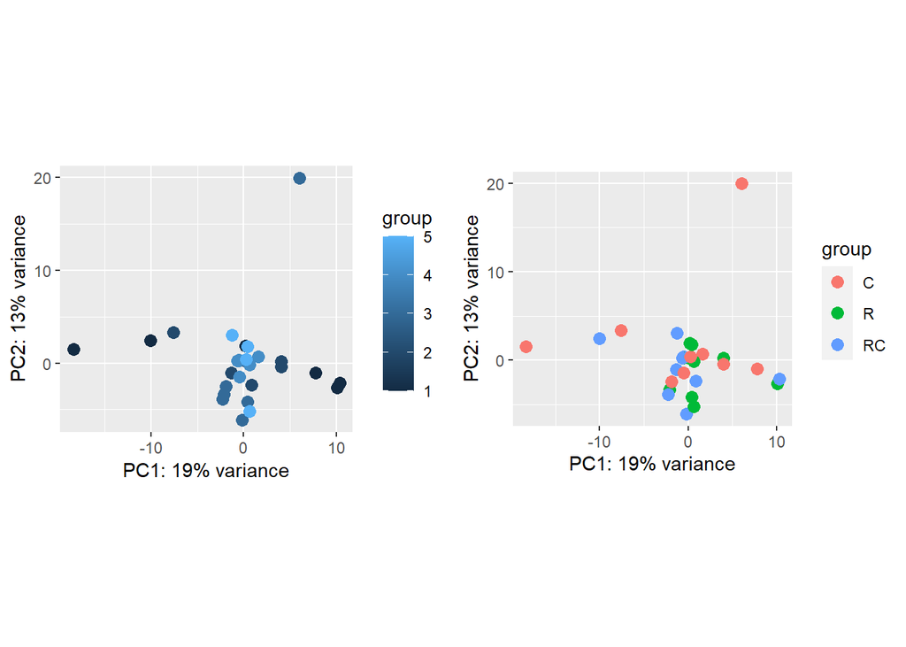

```r
es_vsd_acc_remFP <- es_vsd_acc
assay(es_vsd_acc_remFP) <- limma::removeBatchEffect(assay(es_vsd_acc_remFP), es_vsd_acc_remFP$field_pair)

p1_ESacc_EP_corr <- plotPCA(es_vsd_acc_remFP, "field_pair")
p2_ESacc_treat_corr <- plotPCA(es_vsd_acc_remFP, "treatment")
plot_grid(p1_ESacc_EP_corr, p2_ESacc_treat_corr)
```

```r
#PERMANOVA
es_vsd_acc_remFP_df <- as.data.frame(assay(es_vsd_acc_remFP))
es_vsd_acc_remFP_df <- t(es_vsd_acc_remFP_df)

set.seed(4364)
adonis2(es_vsd_acc_remFP_df ~ treatment,
                     data=es_metadat, permutations=999)
```

```
## Permutation test for adonis under reduced model
## Terms added sequentially (first to last)
## Permutation: free
## Number of permutations: 999
##
## adonis2(formula = es_vsd_acc_remFP_df ~ treatment, data = es_metadat, permutations = 999)
##           Df  SumOfSqs      R2      F Pr(>F)
## treatment  2 0.0012074 0.07162 0.9643  0.536
## Residual  25 0.0156515 0.92838
## Total     27 0.0168589 1.00000
```

*No drought effect on ID level after batch correction*